# Association with a sea anemone alters the skin microbiome of clownfish

# Assigning Taxonomy

We assigned taxonomy for amplicon sequence variants using the Silva v138 reference database. All parameters were conserved from the database presets.

```r
taxa <- assignTaxonomy(seqtab.nochim, "C:/Users/Maddy/Documents/BI586/fishmicrobes_2021_assign1/silva_nr99_v138_train_set.fa.gz", multithread=TRUE)
taxa <- addSpecies(taxa, "C:/Users/Maddy/Documents/BI586/fishmicrobes_2021_assign1/silva_species_assignment_v138.fa.gz")

taxa.print <- taxa
rownames(taxa.print) <- NULL #this gets rid of all the sequences
#head(taxa) #prints full info, including sequence
head(taxa.print) #this just prints taxonomy
```

We then created a csv file for the taxonomy so that it’s easier to map the sequences for the heatmap.

```r
write.csv(taxa, file="taxa.csv",row.name=TRUE,quote=FALSE)
unname(head(taxa, 30))
unname(taxa)
```

Then, we saved our outputs so we can come back to the analysis stage at a later point if desired.

```r
saveRDS(seqtab.nochim, file="final_seqtab_nochim.rds")
saveRDS(taxa, file="final_taxa_blastCorrected.rds")
```

Here is how we can read in previously saved datafiles to avoid re-running the large datasets above.

```r
seqtab.nochim <- readRDS("final_seqtab_nochim.rds")
taxa <- readRDS("final_taxa_blastCorrected.rds")
#head(taxa)
```

We then imported our dataframe containing sample information. Before running this code, we made sure that sample names in the variable table had the same names as the sample names in the taxa and seqtab.nochim files. Samples should also be in the same order as the seqtab file in the rows, and variables as columns.

```r
samdf<-read.csv("variabletable.csv")

head(samdf)
```

```
##       Sample          Sample.Type color Treatment
## 1 SRR6945095                Water     W       WC1
## 2 SRR6945102 Non-Hosting (Week 1)    NH       NH1
## 3 SRR6945105 Pre-Hosting (Week 1)    PH      PH11
## 4 SRR6945110 Non-Hosting (Week 7)    NH       NH7
## 5 SRR6945111 Non-Hosting (Week 5)    NH       NH5
## 6 SRR6945112 Non-Hosting (Week 8)    NH       NH8
```

```r
#head(otu_table(seqtab.nochim, FALSE))
#head(taxa)
rownames(samdf) <- samdf$Sample
```

We then constructed the phyloseq object.

```r
ps <- phyloseq(otu_table(seqtab.nochim, taxa_are_rows=FALSE),
               sample_data(samdf),
               tax_table(taxa))
ps
```

```
## phyloseq-class experiment-level object
## otu_table()   OTU Table:         [ 1797 taxa and 18 samples ]
## sample_data() Sample Data:       [ 18 samples by 4 sample variables ]
## tax_table()   Taxonomy Table:    [ 1797 taxa by 7 taxonomic ranks ]
```

We replaced sequences with names that correspond with the table output.

```r
ids<-taxa_names(ps)
ids <- paste0("sq",seq(1, length(colnames(seqtab.nochim))))
colnames(seqtab.nochim) <- ids
```

Then we created a Barplot to visualize sample microbe colonies.

```r
top90 <- names(sort(taxa_sums(ps), decreasing=TRUE))[1:90]
#isolating top 90 sequences
ps.top90 <- transform_sample_counts(ps, function(OTU) OTU/sum(OTU))
#transforming sequence counts to proportions for visualization
ps.top90 <- prune_taxa(top90, ps.top90)
#removing unwanted (not top90) OTUs (ASVs)
barplot<- plot_bar(ps.top90, x="Sample", fill="Class")
```

To visualize counts rather than abundances:

```r
barplot.count <- plot_bar(ps, x ="Sample", fill= "Class") #+ facet_wrap("tank")
```

We then created a csv file for the phyloseq data. This will give the abundances for each sample and class and is useful for constructing the heatmap. Also, it enables you to use ggplot, and construct more aesthetically pleasing plots.

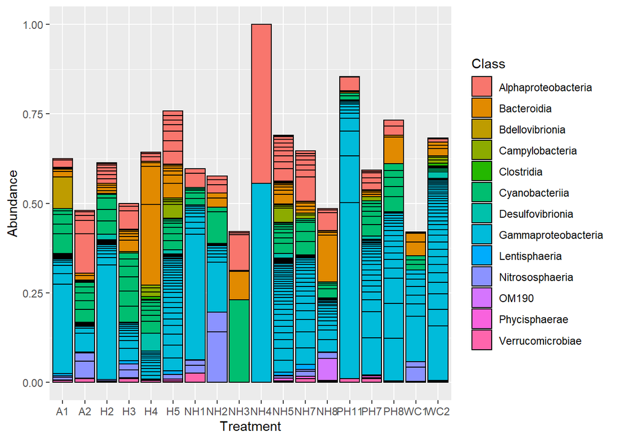

```r
psz <- psmelt(ps.top90)
write.csv(psz, file="Phyloseqoutputfinal.csv")
p <- ggplot(psz, aes(x=Treatment, y=Abundance, fill=Class))
p + geom_bar(stat="identity", colour="black")
```

Here we are looking at Bray Curtis dissimilarities to find if association with anemone has a significant difference on hosting vs. nonhosting clownfish microbiomes.

```r
ord.nmds.bray <- ordinate(ps.top90, method="NMDS", distance="bray")
```

```
## *** Solution reached
```

```r
bray.curtis <-plot_ordination(ps.top90, ord.nmds.bray, color ='color', title="Bray NMDS")
```